# explore and split filtered data for somatic aml

started: AL20May2018  
last updated: AL20May2018  
checked through: MG25May2018 on vep91 annotated data

# Summary

Estimate mean/median coverage

Split into groups:  
- 1 group of filtered variants detected in more than one sample (39 variants total)  
- 4 groups for variants detected in a single sample (one group per sample)

A group of non-filtered variants detected in more than one sample (114 variants)  
was selected earlier (before filtering)

## Prioritising and analyses to be done later

Functional prioritising yet to be done later (in each group separately):  
- Non-coding and synonymous - to exclude  
- Missenses with low impact - to exclude  
- Missenses with high impact - to keep, assuming either loss or gain of function  
- LoF - to keep, assuming anti-oncogenes inactivation  
- Genes of interest for ALL or other results for this patient

Dynamic analysis (yet to be done):  
- Select variants with consistent sequential accumulation of somatic mutations in samples  
- Select variants with “disappearing” of somatic variants in later samples

Other analyses that could be theoretically considered:  
- further functional exploration: e.g. network/interaction, GO, HPO etc analyses  
- assessment of somatic mutational signatiures: the dynamic assessment may look interesting in the paper (+ local collaboration?)  
- assessment of clones within tumour: again, dynamic assessment of clones may look interesting in the paper (is it challenging??)

Assessment of LoH cannot be done until further reading about Mutect algorithm  
Assessment of compound hets is not possible because of non-phased data

# start_section

```r
Sys.time()
```

```
## [1] "2018-05-25 16:25:37 BST"
```

```r
rm(list=ls())
graphics.off()

library(knitr)
base_folder="/rds/project/erf33/rds-erf33-medgen/users/mae/IHCAP75_atm_aml/ihcap_75_somatic_v2/filtering_somatic_with_AL_vep91/"
setwd(base_folder)
opts_knit$set(root.dir = base_folder)

#library(dplyr)
```

# read_data

```r
load("s02_filter.RData")
rm(min_tumour_alt_fraction, min_normal_dp, max_normal_alt_count, min_tumour_dp, min_tumour_alt_count)
```

# check data

```r
ls()
```

```
##  [1] "ad_raw_multi_sample.df"           "ad.df"                            "alt_fraction.mx"                  "alt_raw_fraction_multi_sample.mx" "base_folder"                      "dp_alt.mx"                        "dp_raw_alt_multi_sample.mx"       "dp_raw_multi_sample.mx"           "dp_raw_ref_…
```

```r
dim(gt_add.df)
```

```
## [1] 579   8
```

```r
str(gt_add.df)
```

```
## 'data.frame':    579 obs. of  8 variables:
##  $ IHCAP75_1F_N: int  NA NA NA NA NA 0 NA 0 0 NA ...
##  $ IHCAP75_1F_T: int  NA NA NA NA NA 1 NA 1 1 NA ...
##  $ IHCAP75_BM_N: int  NA 0 NA NA NA NA NA 0 0 NA ...
##  $ IHCAP75_BM_T: int  NA 1 NA NA NA NA NA 1 1 NA ...
##  $ IHCAP75_T1_N: int  NA NA 0 0 0 NA 0 0 0 0 ...
##  $ IHCAP75_T1_T: int  NA NA 1 1 1 NA 1 1 1 1 ...
##  $ IHCAP75_T2_N: int  0 NA NA NA NA NA NA 0 0 NA ...
##  $ IHCAP75_T2_T: int  1 NA NA NA NA NA NA 1 1 NA ...
```

```r
gt_add.df[1:5,1:5]
```

```
##              IHCAP75_1F_N IHCAP75_1F_T IHCAP75_BM_N IHCAP75_BM_T IHCAP75_T1_N
## Var000000009           NA           NA           NA           NA           NA
## Var000000028           NA           NA            0            1           NA
## Var000000032           NA           NA           NA           NA            0
## Var000000051           NA           NA           NA           NA            0
## Var000000071           NA           NA           NA           NA            0
```

```r
dim(ad.df)
```

```
## [1] 579   9
```

```r
str(ad.df)
```

```
## 'data.frame':    579 obs. of  9 variables:
##  $ SplitVarID  : Factor w/ 7608 levels "Var000000001",..: 9 28 32 51 71 76 101 124 132 145 ...
##  $ IHCAP75_1F_N: Factor w/ 540 levels "100,0","100,1",..: NA NA NA NA NA 522 NA 537 35 NA ...
##  $ IHCAP75_1F_T: Factor w/ 776 levels "0,2","10,2","10,4",..: NA NA NA NA NA 512 NA 474 462 NA ...
##  $ IHCAP75_BM_N: Factor w/ 513 levels "10,0","100,0",..: NA 342 NA NA NA NA NA 512 33 NA ...
##  $ IHCAP75_BM_T: Factor w/ 863 levels "0,2","0,4","10,5",..: NA 415 NA NA NA NA NA 520 591 NA ...
##  $ IHCAP75_T1_N: Factor w/ 443 levels "100,0","100,1",..: NA NA 1 127 443 NA 61 443 25 80 ...
##  $ IHCAP75_T1_T: Factor w/ 447 levels "0,2","10,14",..: NA NA 206 206 163 NA 201 28 186 201 ...
##  $ IHCAP75_T2_N: Factor w/ 477 levels "100,0","100,1",..: 454 NA NA NA NA NA NA 476 31 NA ...
##  $ IHCAP75_T2_T: Factor w/ 539 levels "0,2","0,7","10,3",..: 204 NA NA NA NA NA NA 108 294 NA ...
```

```r
ad.df[1:5,1:5]
```

```
##                SplitVarID IHCAP75_1F_N IHCAP75_1F_T IHCAP75_BM_N IHCAP75_BM_T
## Var000000009 Var000000009         <NA>         <NA>         <NA>         <NA>
## Var000000028 Var000000028         <NA>         <NA>         35,0         25,4
## Var000000032 Var000000032         <NA>         <NA>         <NA>         <NA>
## Var000000051 Var000000051         <NA>         <NA>         <NA>         <NA>
## Var000000071 Var000000071         <NA>         <NA>         <NA>         <NA>
```

```r
dim(vv.df)
```

```
## [1] 579  60
```

```r
str(vv.df)
```

```
## 'data.frame':    579 obs. of  60 variables:
##  $ SplitVarID        : Factor w/ 7608 levels "Var000000001",..: 9 28 32 51 71 76 101 124 132 145 ...
##  $ ID                : Factor w/ 360 levels "rs10096369","rs10257529",..: NA NA NA NA NA NA NA NA NA NA ...
##  $ CHROM             : Factor w/ 23 levels "1","10","11",..: 1 1 1 1 1 1 1 1 1 1 ...
##  $ POS               : int  1139436 2560818 3548110 9782163 12066555 12819282 17981131 22159874 23689154 26370909 ...
##  $ REF               : Factor w/ 226 levels "A","AAAAAG","AAAAC",..: 59 73 59 59 59 59 59 59 105 59 ...
##  $ ALT               : Factor w/ 170 levels "A","AAAAAAAG",..: 1 34 1 1 1 1 1 123 1 1 ...
##  $ QUAL              : int  -10 -10 -10 -10 -10 -10 -10 -10 -10 -10 ...
##  $ FILTER            : Factor w/ 1 level "PASS": 1 1 1 1 1 1 1 1 1 1 ...
##  $ AC                : int  1 1 1 1 1 1 1 4 4 1 ...
##  $ AF                : num  0.25 0.25 0.25 0.25 0.25 0.25 0.25 0.25 0.25 0.25 ...
##  $ AN                : int  4 4 4 4 4 4 4 16 16 4 ...
##  $ Location          : Factor w/ 7608 levels "1:100330128",..: 52 534 590 765 85 95 295 436 498 539 ...
##  $ Allele            : Factor w/ 139 levels "-","A","AA","AAA",..: 2 1 2 2 2 2 2 112 2 2 ...
##  $ Uploaded_variation: Factor w/ 361 levels ".","rs10096369",..: 1 1 1 1 1 1 1 1 1 1 ...
```

[output cut: 46 more lines]

```r
vv.df[1:5,1:6]
```

```
##                SplitVarID   ID CHROM      POS  REF ALT
## Var000000009 Var000000009 <NA>     1  1139436    C   A
## Var000000028 Var000000028 <NA>     1  2560818 CCAG   C
## Var000000032 Var000000032 <NA>     1  3548110    C   A
## Var000000051 Var000000051 <NA>     1  9782163    C   A
## Var000000071 Var000000071 <NA>     1 12066555    C   A
```

```r
dim(dp.mx)
```

```
## [1] 579   8
```

```r
dp.mx[1:5,1:5]
```

```
##              IHCAP75_1F_N IHCAP75_1F_T IHCAP75_BM_N IHCAP75_BM_T IHCAP75_T1_N
## Var000000009           NA           NA           NA           NA           NA
## Var000000028           NA           NA           35           29           NA
## Var000000032           NA           NA           NA           NA          100
## Var000000051           NA           NA           NA           NA          179
## Var000000071           NA           NA           NA           NA           99
```

```r
dim(dp_ref.mx)
```

```
## [1] 579   8
```

```r
dp_ref.mx[1:5,1:5]
```

```
##              IHCAP75_1F_N IHCAP75_1F_T IHCAP75_BM_N IHCAP75_BM_T IHCAP75_T1_N
## Var000000009           NA           NA           NA           NA           NA
## Var000000028           NA           NA           35           25           NA
## Var000000032           NA           NA           NA           NA          100
## Var000000051           NA           NA           NA           NA          179
## Var000000071           NA           NA           NA           NA           99
```

```r
dim(dp_alt.mx)
```

```
## [1] 579   8
```

```r
dp_alt.mx[1:5,1:5]
```

```
##              IHCAP75_1F_N IHCAP75_1F_T IHCAP75_BM_N IHCAP75_BM_T IHCAP75_T1_N
## Var000000009           NA           NA           NA           NA           NA
## Var000000028           NA           NA            0            4           NA
## Var000000032           NA           NA           NA           NA            0
## Var000000051           NA           NA           NA           NA            0
## Var000000071           NA           NA           NA           NA            0
```

```r
# check that data are in sync
sum(rownames(gt_add.df) != rownames(ad.df))
```

```
## [1] 0
```

```r
sum(rownames(gt_add.df) != rownames(dp.mx))
```

```
## [1] 0
```

```r
sum(rownames(gt_add.df) != rownames(dp_ref.mx))
```

```
## [1] 0
```

```r
sum(rownames(gt_add.df) != rownames(dp_alt.mx))
```

```
## [1] 0
```

```r
sum(rownames(gt_add.df) != rownames(vv.df))
```

```
## [1] 0
```

```r
# count 0-1-NA genotypes
summary(as.factor(as.matrix(gt_add.df)))
```

```
##    0    1 NA's
##  674  674 3284
```

```r
# no variants with with all NA genotypes
all_na.udf <- function(x){all(is.na(x))}
all_na_variants <- apply(gt_add.df,1,all_na.udf)
sum(all_na_variants)
```

```
## [1] 0
```

```r
sum(!all_na_variants)
```

```
## [1] 579
```

```r
# clean-up
rm(all_na.udf,all_na_variants)
```

# mean/median coverage in filtered data

```r
# cumulative depth
mean(dp.mx, na.rm=T)
```

```
## [1] 79.0844
```

```r
median(dp.mx, na.rm=T)
```

```
## [1] 51
```

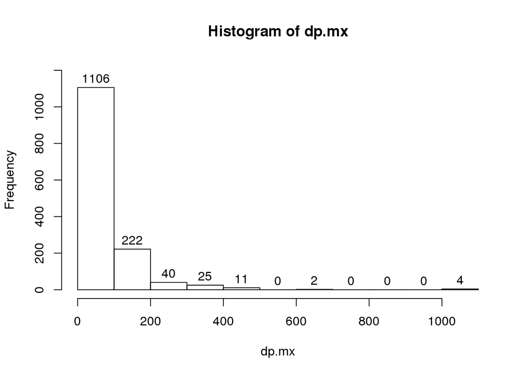

```r
hist(dp.mx, labels = T, ylim=c(0,1200))
```

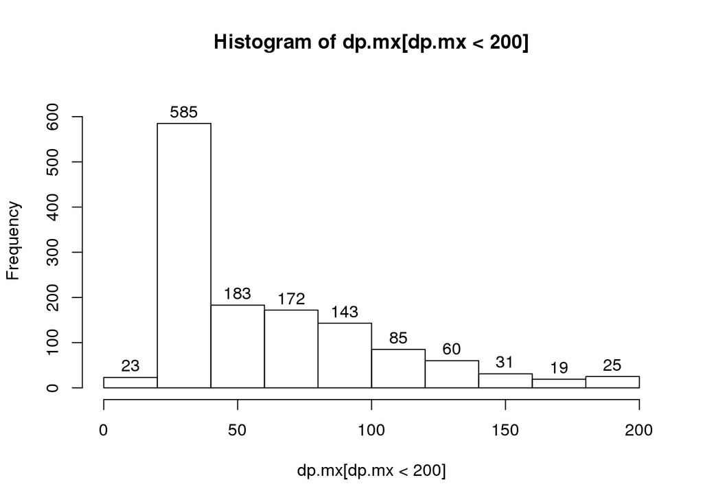

```r
hist(dp.mx[dp.mx<200], labels = T, ylim=c(0,650))
```

# select filtered variants present in multiple samples

Immediately noticeable: **a known pathogenic KRAS variant** (rs104894362) is present in each tumour sample  
KRAS was previously related to ALL e.g. see https://www.nature.com/articles/leu2015107

Also interesting: **a double-hit may be noted in IL7R** (Var000002144, Var000002145)  
IL7R also was previously related to ALL: https://www.nature.com/articles/ng.924

I had no time to look further at this stage. However, some other genes may also ring a bell.

```r
call_count.udf <- function(gt_vector){sum(!is.na(gt_vector))}
call_counts <- apply(gt_add.df,1,call_count.udf)
table(call_counts)
```

```
## call_counts
##   2   4   6   8
## 540   9   4  26
```

```r
# Index of variants present in single sample only
single_sample_variants <- call_counts == 2

# Tables with variants detected in multiple samples
gt_multi_sample.df <- gt_add.df[!single_sample_variants,]
dim(gt_multi_sample.df)
```

```
## [1] 39  8
```

```r
gt_multi_sample.df
```

```
##              IHCAP75_1F_N IHCAP75_1F_T IHCAP75_BM_N IHCAP75_BM_T IHCAP75_T1_N IHCAP75_T1_T IHCAP75_T2_N IHCAP75_T2_T
## Var000000124            0            1            0            1            0            1            0            1
## Var000000132            0            1            0            1            0            1            0            1
## Var000000306           NA           NA            0            1            0            1            0            1
## Var000001049            0            1            0            1            0            1            0            1
## Var000001271            0            1            0            1            0            1            0            1
## Var000001433           NA           NA            0            1            0            1           NA           NA
## Var000001554            0            1            0            1            0            1            0            1
## Var000001679            0            1           NA           NA           NA           NA            0            1
## Var000001705            0            1            0            1            0            1            0            1
## Var000001739            0            1            0            1            0            1            0            1
## Var000001784           NA           NA           NA           NA            0            1            0            1
## Var000001975           NA           NA           NA           NA            0            1            0            1
## Var000002090            0            1            0            1            0            1            0            1
## Var000002144            0            1            0            1           NA           NA            0            1
## Var000002145            0            1            0            1           NA           NA            0            1
## Var000002363            0            1            0            1            0            1            0            1
## Var000002756            0            1            0            1            0            1            0            1
## Var000003502            0            1            0            1            0            1            0            1
## Var000003695            0            1            0            1            0            1            0            1
## Var000003889            0            1           NA           NA            0            1            0            1
## Var000003972            0            1            0            1           NA           NA           NA           NA
## Var000003986            0            1            0            1            0            1            0            1
## Var000003996            0            1            0            1            0            1            0            1
## Var000004403            0            1            0            1            0            1            0            1
## Var000004561            0            1            0            1            0            1            0            1
## Var000005134            0            1            0            1            0            1            0            1
## Var000005234            0            1            0            1            0            1            0            1
## Var000005642            0            1            0            1            0            1            0            1
## Var000005752            0            1           NA           NA            0            1           NA           NA
## Var000005819            0            1            0            1            0            1            0            1
## Var000006242            0            1            0            1            0            1            0            1
## Var000006354           NA           NA           NA           NA            0            1            0            1
## Var000006400            0            1            0            1            0            1            0            1
## Var000006850            0            1            0            1            0            1            0            1
## Var000006864           NA           NA            0            1            0            1           NA           NA
## Var000007303           NA           NA            0            1            0            1           NA           NA
## Var000007444            0            1            0            1            0            1            0            1
## Var000007489            0            1            0            1            0            1            0            1
## Var000007506            0            1            0            1            0            1            0            1
```

```r
vv_multi_sample.df <- vv.df[!single_sample_variants,]
dim(vv_multi_sample.df)
```

```
## [1] 39 60
```

```r
vv_multi_sample.df
```

```
##                SplitVarID          ID CHROM       POS     REF  ALT QUAL FILTER AC   AF AN              Location Allele Uploaded_variation    SYMBOL                          Consequence   IMPACT     Codons Amino_acids cDNA_position CDS_position Protein_position VARIANT_CLASS                       …
## Var000000124 Var000000124        <NA>     1  22159874       C    T  -10   PASS  4 0.25 16            1:22159874      T                  .     HSPG2                     missense_variant MODERATE    cGg/cAg         R/Q         11062        10982             3661           SNV                       …
## Var000000132 Var000000132        <NA>     1  23689154       G    A  -10   PASS  4 0.25 16            1:23689154      A                  .    ZNF436                          stop_gained     HIGH    Caa/Taa         Q/*           858          721              241           SNV                       …
## Var000000306 Var000000306        <NA>     1  65304237       G    A  -10   PASS  4 0.25 16            1:65304237      A                  .      JAK1                     missense_variant MODERATE    Cct/Tct         P/S          3127         2878              960           SNV                       …
## Var000001049 Var000001049 rs371215860     2 130900259       C    T  -10   PASS  4 0.25 16           2:130900259      T        rs371215860   CCDC74B                       intron_variant MODIFIER       <NA>        <NA>          <NA>         <NA>             <NA>           SNV                       …
## Var000001271 Var000001271        <NA>     2 228137819       C    A  -10   PASS  4 0.25 16           2:228137819      A                  .    COL4A3                     missense_variant MODERATE    cCa/cAa         P/Q          2075         1913              638           SNV                       …
## Var000001433 Var000001433        <NA>     3  48219320   AACAC    A  -10   PASS  3 0.25 12   3:48219321-48219324      -                  .    CDC25A                       intron_variant MODIFIER       <NA>        <NA>          <NA>         <NA>             <NA>      deletion                       …
## Var000001554 Var000001554        <NA>     3  96706639       C    T  -10   PASS  4 0.25 16            3:96706639      T                  .     EPHA6                     missense_variant MODERATE    Cgt/Tgt         R/C           954          916              306           SNV             COSM359802…
## Var000001679 Var000001679        <NA>     3 160474137       G    T  -10   PASS  3 0.25 12           3:160474137      T                  .     PPM1L                     missense_variant MODERATE    cGc/cTc         R/L           142           41               14           SNV                       …
## Var000001705 Var000001705        <NA>     3 176750793       G    T  -10   PASS  4 0.25 16           3:176750793      T                  .   TBL1XR1                     missense_variant MODERATE    tCt/tAt         S/Y          1642         1382              461           SNV                       …
## Var000001739 Var000001739        <NA>     3 192517076       A    G  -10   PASS  4 0.25 16           3:192517076      G                  .    MB21D2                     missense_variant MODERATE    aTc/aCc         I/T           896          575              192           SNV                       …
## Var000001784 Var000001784        <NA>     4   1809110     CTG    C  -10   PASS  2 0.25  8     4:1809111-1809112      -                  .     FGFR3                  3_prime_UTR_variant MODIFIER       <NA>        <NA>     2805-2806         <NA>             <NA>      deletion           rs754209375&…
## Var000001975 Var000001975        <NA>     4 103553447     GAA    G  -10   PASS  2 0.25  8 4:103553448-103553449      -                  .     MANBA                       intron_variant MODIFIER       <NA>        <NA>          <NA>         <NA>             <NA>      deletion                       …
## Var000002090 Var000002090        <NA>     4 189022339       A    G  -10   PASS  4 0.25 16           4:189022339      G                  .    TRIML2                   synonymous_variant      LOW    aaT/aaC           N           576          201               67           SNV COSM1169021&COSM339282…
## Var000002144 Var000002144        <NA>     5  35874595       T TGCC  -10   PASS  4 0.25 16   5:35874595-35874596    GCC                  .      IL7R             protein_altering_variant MODERATE ttc/tGCCtc        F/CL       880-881      751-752              251     insertion                       …
## Var000002145 Var000002145        <NA>     5  35874596       T    A  -10   PASS  4 0.25 16            5:35874596      A                  .      IL7R                     missense_variant MODERATE    tTc/tAc         F/Y           881          752              251           SNV                       …
## Var000002363 Var000002363        <NA>     5 151180366       T    A  -10   PASS  4 0.25 16           5:151180366      A                  .     G3BP1                          stop_gained     HIGH    tTa/tAa         L/*          1275         1130              377           SNV                       …
```

[output cut: 63 more lines]

```r
ad_multi_sample.df <- ad.df[!single_sample_variants,]
dim(ad_multi_sample.df)
```

```
## [1] 39  9
```

```r
ad_multi_sample.df
```

```
##                SplitVarID IHCAP75_1F_N IHCAP75_1F_T IHCAP75_BM_N IHCAP75_BM_T IHCAP75_T1_N IHCAP75_T1_T IHCAP75_T2_N IHCAP75_T2_T
## Var000000124 Var000000124         98,0        32,22         99,0        34,27         99,0        11,10         98,0        14,17
## Var000000132 Var000000132        116,0        31,19        116,0        43,29        118,0        29,11        118,0        36,20
## Var000000306 Var000000306        227,0        215,6        227,0       147,49        229,0        79,25        228,0       104,28
## Var000001049 Var000001049        423,0       167,96        426,0       155,93        424,0        67,33        426,0        86,61
## Var000001271 Var000001271        406,0       26,111        404,0       55,103        409,0        35,53        405,0        25,88
## Var000001433 Var000001433         63,0         55,3         63,0         65,8         63,0         29,8         <NA>         <NA>
## Var000001554 Var000001554         80,0        29,19         81,0        32,22         81,0         17,9         78,0        20,22
## Var000001679 Var000001679         59,0        33,12         59,0         49,3         <NA>         <NA>         58,0         24,7
## Var000001705 Var000001705         82,0        34,25         82,0        67,44         83,0        29,16         82,0        52,18
## Var000001739 Var000001739        358,0      143,121        358,0      211,124        357,0       119,67        354,0       102,90
## Var000001784 Var000001784         <NA>         <NA>         <NA>         <NA>         52,1         28,6         52,1        66,10
## Var000001975 Var000001975         <NA>         <NA>         <NA>         <NA>         53,1         27,8         52,1        29,10
## Var000002090 Var000002090        156,0        53,65        156,0       103,79        156,0        63,23        157,0        76,35
## Var000002144 Var000002144        348,0      131,130        350,0       361,43        348,0       177,10        348,0       184,35
## Var000002145 Var000002145        353,0      135,128        355,0       362,45        353,0       179,10        353,0       185,36
## Var000002363 Var000002363        163,0        10,58        163,0        36,37        163,0        11,52        164,0         7,69
## Var000002756 Var000002756        198,0        92,61        201,0       144,67        201,0       102,43        198,0       115,66
## Var000003502 Var000003502        376,0      168,129        379,0      144,106        376,0       105,63        379,0        96,79
## Var000003695 Var000003695         82,1        29,17         82,1        29,20         82,1         6,16         82,1        19,22
## Var000003889 Var000003889         71,0        20,11         71,0         57,5         71,0         29,6         71,0        31,13
## Var000003972 Var000003972         28,0         15,6         28,0         15,8         <NA>         <NA>         28,0         10,4
## Var000003986 Var000003986         66,1        34,19         66,1        44,30         66,1        29,15         66,1        33,13
## Var000003996 Var000003996        193,0        77,45        193,0        79,54        193,0        58,23        194,0        46,43
## Var000004403 Var000004403        200,0        59,37        198,0        71,66        199,0        36,11        200,0        29,42
## Var000004561 Var000004561        297,0      104,108        297,0       152,95        297,0        74,56        303,0        94,63
## Var000005134 Var000005134        113,0        36,35        116,0        31,24        112,0        28,11        116,0         17,9
## Var000005234 Var000005234         73,0        38,17         73,0        51,28         73,0        31,18         73,0        30,26
## Var000005642 Var000005642        134,0        49,43        134,0        53,36        135,0        43,21        134,0        40,27
## Var000005752 Var000005752         34,1         30,4         35,0         72,7         34,0         26,4         <NA>         <NA>
## Var000005819 Var000005819        342,0       116,99        342,0      184,103        342,0        79,59        341,0       117,86
## Var000006242 Var000006242        186,0        76,56        186,0        77,52        185,0        46,18        190,0        51,32
## Var000006354 Var000006354         <NA>         <NA>         <NA>         <NA>        115,0         36,6        113,0        75,10
## Var000006400 Var000006400       1012,0      443,212       1005,0      546,152       1002,0       266,70       1007,0       282,95
## Var000006850 Var000006850         66,0        22,19         67,0        48,22         66,0        27,13         67,0        41,30
## Var000006864 Var000006864         <NA>         <NA>         47,0         34,4         48,0         20,4         <NA>         <NA>
## Var000007303 Var000007303         <NA>         <NA>         49,0        14,16         49,0        10,14         <NA>         <NA>
## Var000007444 Var000007444        141,0        40,41        141,0        64,52        143,0        32,14        142,0        40,17
## Var000007489 Var000007489        131,0        50,47        128,0        38,53        131,0        32,15        131,0        38,17
## Var000007506 Var000007506        256,0       103,70        256,0       102,68        256,0        47,22        254,0        55,33
```

```r
dp_multi_sample.mx <- dp.mx[!single_sample_variants,]
dim(dp_multi_sample.mx)
```

```
## [1] 39  8
```

```r
dp_ref_multi_sample.mx <- dp_ref.mx[!single_sample_variants,]
dim(dp_ref_multi_sample.mx)
```

```
## [1] 39  8
```

```r
dp_alt_multi_sample.mx <- dp_alt.mx[!single_sample_variants,]
dim(dp_alt_multi_sample.mx)
```

```
## [1] 39  8
```

```r
alt_fraction_multi_sample.mx <- alt_fraction.mx[!single_sample_variants,]
dim(alt_fraction_multi_sample.mx)
```

```
## [1] 39  8
```

```r
# export 39 variants in more than one sample
dim(gt_multi_sample.df) # 39 x 8
```

```
## [1] 39  8
```

```r
dim(ad_multi_sample.df) # 39 x 9
```

```
## [1] 39  9
```

```r
dim(vv_multi_sample.df) # 39 x 30
```

```
## [1] 39 60
```

```r
ihcap75_39_gtvv_merged.mx <- as.matrix(merge(vv_multi_sample.df, gt_multi_sample.df, by="row.names"))
dim(ihcap75_39_gtvv_merged.mx) # 39 x 39
```

```
## [1] 39 69
```

```r
write.table(ihcap75_39_gtvv_merged.mx, "/rds/project/erf33/rds-erf33-medgen/users/mae/IHCAP75_atm_aml/ihcap_75_somatic_v2/filtering_somatic_with_AL_vep91/ihcap75_39_gtvv_merged.txt", quote = FALSE, sep = "\t", row.names=FALSE, col.names=TRUE)

ihcap75_39_advv_merged.mx <- as.matrix(merge(vv_multi_sample.df, ad_multi_sample.df, by="row.names"))
dim(ihcap75_39_advv_merged.mx) # 39 x 40
```

```
## [1] 39 70
```

```r
write.table(ihcap75_39_advv_merged.mx, "/rds/project/erf33/rds-erf33-medgen/users/mae/IHCAP75_atm_aml/ihcap_75_somatic_v2/filtering_somatic_with_AL_vep91/ihcap75_39_advv_merged.txt", quote = FALSE, sep = "\t", row.names=FALSE, col.names=TRUE)

ihcap75_39_gtadvv_merged.mx <- as.matrix(merge(ihcap75_39_gtvv_merged.mx, ad_multi_sample.df, by="SplitVarID"))
dim(ihcap75_39_gtadvv_merged.mx) # 39 x 47
```

```
## [1] 39 77
```

```r
write.table(ihcap75_39_gtadvv_merged.mx, "/rds/project/erf33/rds-erf33-medgen/users/mae/IHCAP75_atm_aml/ihcap_75_somatic_v2/filtering_somatic_with_AL_vep91/ihcap75_39_gtadvv_merged.txt", quote = FALSE, sep = "\t", row.names=FALSE, col.names=TRUE)

# clean-up
rm(call_counts, call_count.udf, ihcap75_39_gtvv_merged.mx, ihcap75_39_advv_merged.mx, ihcap75_39_gtadvv_merged.mx)
```

# select filtered variants present in a single sample only

```r
gt_single_sample.df <- gt_add.df[single_sample_variants,]
dim(gt_single_sample.df)
```

```
## [1] 540   8
```

```r
vv_single_sample.df <- vv.df[single_sample_variants,]
dim(vv_single_sample.df)
```

```
## [1] 540  60
```

```r
ad_single_sample.df <- ad.df[single_sample_variants,]
dim(ad_single_sample.df)
```

```
## [1] 540   9
```

```r
dp_single_sample.mx <- dp.mx[single_sample_variants,]
dim(dp_single_sample.mx)
```

```
## [1] 540   8
```

```r
dp_ref_single_sample.mx <- dp_ref.mx[single_sample_variants,]
dim(dp_ref_single_sample.mx)
```

```
## [1] 540   8
```

```r
dp_alt_single_sample.mx <- dp_alt.mx[single_sample_variants,]
dim(dp_alt_single_sample.mx)
```

```
## [1] 540   8
```

```r
alt_fraction_single_sample.mx <- alt_fraction.mx[single_sample_variants,]
dim(alt_fraction_single_sample.mx)
```

```
## [1] 540   8
```

```r
ihcap75_540_gtvv_merged.mx <- as.matrix(merge(vv_single_sample.df, gt_single_sample.df, by="row.names"))
dim(ihcap75_540_gtvv_merged.mx) # 540 x 69
```

```
## [1] 540  69
```

```r
write.table(ihcap75_540_gtvv_merged.mx, "/rds/project/erf33/rds-erf33-medgen/users/mae/IHCAP75_atm_aml/ihcap_75_somatic_v2/filtering_somatic_with_AL_vep91/ihcap75_540_gtvv_merged.txt", quote = FALSE, sep = "\t", row.names=FALSE, col.names=TRUE)

ihcap75_540_gtadvv_merged.mx <- as.matrix(merge(ihcap75_540_gtvv_merged.mx, ad_single_sample.df, by="SplitVarID"))
dim(ihcap75_540_gtadvv_merged.mx) # 540 x 77
```

```
## [1] 540  77
```

```r
write.table(ihcap75_540_gtadvv_merged.mx, "/rds/project/erf33/rds-erf33-medgen/users/mae/IHCAP75_atm_aml/ihcap_75_somatic_v2/filtering_somatic_with_AL_vep91/ihcap75_540_gtadvv_merged.txt", quote = FALSE, sep = "\t", row.names=FALSE, col.names=TRUE)

rm(single_sample_variants, ihcap75_540_gtvv_merged.mx, ihcap75_540_gtadvv_merged.mx)
```

# select variants present in IHCAP75_1F only

```r
selected_variants <- which(gt_single_sample.df$IHCAP75_1F_T == 1)
length(selected_variants)
```

```
## [1] 106
```

```r
gt_IHCAP75_1F.df <- gt_single_sample.df[selected_variants,]
dim(gt_IHCAP75_1F.df)
```

```
## [1] 106   8
```

```r
gt_IHCAP75_1F.df[1:5,]
```

```
##              IHCAP75_1F_N IHCAP75_1F_T IHCAP75_BM_N IHCAP75_BM_T IHCAP75_T1_N IHCAP75_T1_T IHCAP75_T2_N IHCAP75_T2_T
## Var000000076            0            1           NA           NA           NA           NA           NA           NA
## Var000000158            0            1           NA           NA           NA           NA           NA           NA
## Var000000171            0            1           NA           NA           NA           NA           NA           NA
## Var000000192            0            1           NA           NA           NA           NA           NA           NA
## Var000000201            0            1           NA           NA           NA           NA           NA           NA
```

```r
vv_IHCAP75_1F.df <- vv_single_sample.df[selected_variants,]
dim(vv_IHCAP75_1F.df)
```

```
## [1] 106  60
```

```r
ad_IHCAP75_1F.df <- ad_single_sample.df[selected_variants,]
dim(ad_IHCAP75_1F.df)
```

```
## [1] 106   9
```

```r
dp_IHCAP75_1F.mx <- dp_single_sample.mx[selected_variants,]
dim(dp_IHCAP75_1F.mx)
```

```
## [1] 106   8
```

```r
dp_ref_IHCAP75_1F.mx <- dp_ref_single_sample.mx[selected_variants,]
dim(dp_ref_IHCAP75_1F.mx)
```

```
## [1] 106   8
```

```r
dp_alt_IHCAP75_1F.mx <- dp_alt_single_sample.mx[selected_variants,]
dim(dp_alt_IHCAP75_1F.mx)
```

```
## [1] 106   8
```

```r
alt_fraction_IHCAP75_1F.mx <- alt_fraction_single_sample.mx[selected_variants,]
dim(alt_fraction_IHCAP75_1F.mx)
```

```
## [1] 106   8
```

```r
rm(selected_variants)
```

# select variants present in IHCAP75_BM only

```r
selected_variants <- which(gt_single_sample.df$IHCAP75_BM_T == 1)
length(selected_variants)
```

```
## [1] 78
```

```r
gt_IHCAP75_BM.df <- gt_single_sample.df[selected_variants,]
dim(gt_IHCAP75_BM.df)
```

```
## [1] 78  8
```

```r
gt_IHCAP75_BM.df[1:5,]
```

```
##              IHCAP75_1F_N IHCAP75_1F_T IHCAP75_BM_N IHCAP75_BM_T IHCAP75_T1_N IHCAP75_T1_T IHCAP75_T2_N IHCAP75_T2_T
## Var000000028           NA           NA            0            1           NA           NA           NA           NA
## Var000000283           NA           NA            0            1           NA           NA           NA           NA
## Var000000310           NA           NA            0            1           NA           NA           NA           NA
## Var000000330           NA           NA            0            1           NA           NA           NA           NA
## Var000000375           NA           NA            0            1           NA           NA           NA           NA
```

```r
vv_IHCAP75_BM.df <- vv_single_sample.df[selected_variants,]
dim(vv_IHCAP75_BM.df)
```

```
## [1] 78 60
```

```r
ad_IHCAP75_BM.df <- ad_single_sample.df[selected_variants,]
dim(ad_IHCAP75_BM.df)
```

```
## [1] 78  9
```

```r
dp_IHCAP75_BM.mx <- dp_single_sample.mx[selected_variants,]
dim(dp_IHCAP75_BM.mx)
```

```
## [1] 78  8
```

```r
dp_ref_IHCAP75_BM.mx <- dp_ref_single_sample.mx[selected_variants,]
dim(dp_ref_IHCAP75_BM.mx)
```

```
## [1] 78  8
```

```r
dp_alt_IHCAP75_BM.mx <- dp_alt_single_sample.mx[selected_variants,]
dim(dp_alt_IHCAP75_BM.mx)
```

```
## [1] 78  8
```

```r
alt_fraction_IHCAP75_BM.mx <- alt_fraction_single_sample.mx[selected_variants,]
dim(alt_fraction_IHCAP75_BM.mx)
```

```
## [1] 78  8
```

```r
rm(selected_variants)
```

# select variants present in IHCAP75_T1 only

```r
selected_variants <- which(gt_single_sample.df$IHCAP75_T1_T == 1)
length(selected_variants)
```

```
## [1] 192
```

```r
gt_IHCAP75_T1.df <- gt_single_sample.df[selected_variants,]
dim(gt_IHCAP75_T1.df)
```

```
## [1] 192   8
```

```r
gt_IHCAP75_T1.df[1:5,]
```

```
##              IHCAP75_1F_N IHCAP75_1F_T IHCAP75_BM_N IHCAP75_BM_T IHCAP75_T1_N IHCAP75_T1_T IHCAP75_T2_N IHCAP75_T2_T
## Var000000032           NA           NA           NA           NA            0            1           NA           NA
## Var000000051           NA           NA           NA           NA            0            1           NA           NA
## Var000000071           NA           NA           NA           NA            0            1           NA           NA
## Var000000101           NA           NA           NA           NA            0            1           NA           NA
## Var000000145           NA           NA           NA           NA            0            1           NA           NA
```

```r
vv_IHCAP75_T1.df <- vv_single_sample.df[selected_variants,]
dim(vv_IHCAP75_T1.df)
```

```
## [1] 192  60
```

```r
ad_IHCAP75_T1.df <- ad_single_sample.df[selected_variants,]
dim(ad_IHCAP75_T1.df)
```

```
## [1] 192   9
```

```r
dp_IHCAP75_T1.mx <- dp_single_sample.mx[selected_variants,]
dim(dp_IHCAP75_T1.mx)
```

```
## [1] 192   8
```

```r
dp_ref_IHCAP75_T1.mx <- dp_ref_single_sample.mx[selected_variants,]
dim(dp_ref_IHCAP75_T1.mx)
```

```
## [1] 192   8
```

```r
dp_alt_IHCAP75_T1.mx <- dp_alt_single_sample.mx[selected_variants,]
dim(dp_alt_IHCAP75_T1.mx)
```

```
## [1] 192   8
```

```r
alt_fraction_IHCAP75_T1.mx <- alt_fraction_single_sample.mx[selected_variants,]
dim(alt_fraction_IHCAP75_T1.mx)
```

```
## [1] 192   8
```

```r
rm(selected_variants)
```

# select variants present in IHCAP75_T2 only

```r
selected_variants <- which(gt_single_sample.df$IHCAP75_T2_T == 1)
length(selected_variants)
```

```
## [1] 164
```

```r
gt_IHCAP75_T2.df <- gt_single_sample.df[selected_variants,]
dim(gt_IHCAP75_T2.df)
```

```
## [1] 164   8
```

```r
gt_IHCAP75_T2.df[1:5,]
```

```
##              IHCAP75_1F_N IHCAP75_1F_T IHCAP75_BM_N IHCAP75_BM_T IHCAP75_T1_N IHCAP75_T1_T IHCAP75_T2_N IHCAP75_T2_T
## Var000000009           NA           NA           NA           NA           NA           NA            0            1
## Var000000276           NA           NA           NA           NA           NA           NA            0            1
## Var000000281           NA           NA           NA           NA           NA           NA            0            1
## Var000000419           NA           NA           NA           NA           NA           NA            0            1
## Var000000440           NA           NA           NA           NA           NA           NA            0            1
```

```r
vv_IHCAP75_T2.df <- vv_single_sample.df[selected_variants,]
dim(vv_IHCAP75_T2.df)
```

```
## [1] 164  60
```

```r
ad_IHCAP75_T2.df <- ad_single_sample.df[selected_variants,]
dim(ad_IHCAP75_T2.df)
```

```
## [1] 164   9
```

```r
dp_IHCAP75_T2.mx <- dp_single_sample.mx[selected_variants,]
dim(dp_IHCAP75_T2.mx)
```

```
## [1] 164   8
```

```r
dp_ref_IHCAP75_T2.mx <- dp_ref_single_sample.mx[selected_variants,]
dim(dp_ref_IHCAP75_T2.mx)
```

```
## [1] 164   8
```

```r
dp_alt_IHCAP75_T2.mx <- dp_alt_single_sample.mx[selected_variants,]
dim(dp_alt_IHCAP75_T2.mx)
```

```
## [1] 164   8
```

```r
alt_fraction_IHCAP75_T2.mx <- alt_fraction_single_sample.mx[selected_variants,]
dim(alt_fraction_IHCAP75_T2.mx)
```

```
## [1] 164   8
```

```r
rm(selected_variants)
```

# save_results

```r
save.image("s03_split_filtered.RData")
```

# final_section

```r
ls()
```

```
##  [1] "ad_IHCAP75_1F.df"                 "ad_IHCAP75_BM.df"                 "ad_IHCAP75_T1.df"                 "ad_IHCAP75_T2.df"                 "ad_multi_sample.df"               "ad_raw_multi_sample.df"           "ad_single_sample.df"              "ad.df"                            "alt_fractio…
## [29] "dp_multi_sample.mx"               "dp_raw_alt_multi_sample.mx"       "dp_raw_multi_sample.mx"           "dp_raw_ref_multi_sample.mx"       "dp_ref_IHCAP75_1F.mx"             "dp_ref_IHCAP75_BM.mx"             "dp_ref_IHCAP75_T1.mx"             "dp_ref_IHCAP75_T2.mx"             "dp_ref_mult…
## [57] "vv.df"
```

```r
Sys.time()
```

```
## [1] "2018-05-25 16:25:39 BST"
```